# Exploratory Data Analysis, Colorado

Albert Sun

9/30/2020

```r
library(tidyverse)
library(patchwork)
library(janitor)
library(broom)
library(knitr)
```

```r
colorado <- read_csv("HB19-1297Data.csv") %>%
  clean_names()

glimpse(colorado)
```

```
## Rows: 2,280
## Columns: 23
## $ qtr_year          <dbl> 2020, 2020, 2020, 2020, 2020, 2020, 2020, 2020, 2...
## $ qtr               <dbl> 1, 1, 1, 1, 1, 1, 1, 1, 1, 1, 1, 1, 1, 1, 1, 1, 1...
## $ county            <chr> "Clear Creek", "Clear Creek", "Clear Creek", "Cle...
## $ jms               <chr> "E-Force", "E-Force", "E-Force", "E-Force", "E-Fo...
## $ capacity          <dbl> 105, 105, 105, 105, 105, 105, 105, 105, 105, 105,...
## $ beds              <dbl> 105, 105, 105, 105, 105, 105, 105, 105, 105, 105,...
## $ deaths            <dbl> 0, 0, 0, 0, 0, 0, 0, 0, 0, 0, 0, 0, 0, 0, 0, 0, 0...
## $ bookings          <dbl> 253, 253, 253, 253, 253, 253, 253, 253, 253, 253,...
## $ releases          <dbl> 183, 183, 183, 183, 183, 183, 183, 183, 183, 183,...
## $ measure           <chr> "Number of inmates", "Sentenced", "Unsentenced - ...
## $ total             <dbl> 70.0, 2.0, 4.0, 64.0, 53.0, 11.0, 3.0, 5.0, 2.0, ...
## $ male              <dbl> 62, 2, 4, 56, 46, 10, 2, 5, 2, 78, 118, 194, 85, ...
## $ female            <dbl> 8, 0, 0, 8, 7, 1, 1, 0, 0, 14, 93, 46, 128, 115, ...
## $ other_gender      <dbl> 0, 0, 0, 0, 0, 0, 0, 0, 0, 0, 0, 0, 0, 0, 0, 0, 0...
## $ black             <dbl> 10, 1, 1, 8, 8, 0, 1, 2, 0, 12, 19, 23, 26, 27, 0...
## $ native_american   <dbl> 0.0, 0.0, 0.0, 0.0, 0.0, 0.0, 0.0, 0.0, 0.0, 0.6,...
## $ other_race        <dbl> 0.00, 0.00, 0.00, 0.00, 0.00, 0.00, 0.00, 0.00, 0...
## $ white             <dbl> 58, 1, 2, 55, 44, 11, 2, 3, 2, 76, 0, 205, 13, 56...
## $ unknown_race      <dbl> 2.0, 0.0, 1.0, 1.0, 1.0, 0.0, 0.0, 0.0, 0.0, 0.3,...
## $ non_hispanic      <dbl> 43, 2, 2, 39, 31, 8, 2, 5, 2, 56, 178, 161, 16, 4...
## $ hispanic          <dbl> 20, 0, 2, 18, 16, 2, 1, 0, 0, 30, 227, 56, 6, 97,...
## $ unknown_ethnicity <dbl> 7, 0, 0, 7, 6, 1, 0, 0, 0, 6, 46, 23, 10, 85, 0, ...
## $ not_available     <chr> NA, NA, NA, NA, NA, NA, NA, NA, NA, NA, NA, NA, N...
```

# Overall Comments

Overall, the HB 19-1297 data set is the only statewide jail database that offers an open source “.csv” file for the public to see. Even other states who do collect jail population data, like California and Texas, don’t have their data published completely open source; instead, researchers are forced to scrape the data periodically from their website. As such, we find that the HB-1297 data set to be the most reproducible thus far.

The 23 columns represent variables: the quarter, the year, county jail, jail management system, etc.

The 2280 rows generally reflect specific jail information per each quarter; however, the reason why there are 2280 rows instead of 152 rows (the number of jails times three quarters in Colorado) is because each jail has 15 rows separated into different areas of measurement, i.e. “Number of inmates”, “Sentenced”, etc. In more-technical SQL terms, it seems like the measure column was cross joined with jail column.

# 1. Check Proportion Missing

Instead of leaving blank values in missing columns, the Colorado HB 19-1297 jail dataset uses the `not_available` column to annotate and comment on missingness. They add `0` to a datapoint that is missing. Thus, because we cannot use conventional functions like is.na() to detect missingness, we will take a look at the jail observations that contain missing data.

Here are the 10 most common NA messages.

```r
colorado %>%
  count(not_available) %>%
  group_by(not_available) %>%
  arrange(-n) %>%
  ungroup %>%
  slice(1:10)
```

```
## # A tibble: 10 x 2
##    not_available                                                               n
##    <chr>                                                                   <int>
##  1  <NA>                                                                    1792
##  2 "Eforce does not seprate this data"                                        18
##  3 "JMS does not calculate this"                                              18
##  4 "ESTIMATES"                                                                13
##  5 "This is not tracked in our system"                                        13
##  6 "My JMS doesn't break unsentenced inmates by Gender or Race/Ethnicity."    12
##  7 "Not able to capture information"                                          11
##  8 "JMS does not currently break down \"sentenced\" by gender/race/ethnic~    10
##  9 "Not able to caputre information"                                          10
## 10 "Population down due to COVID-19"                                          10
```

Out of 2280 rows, there are 488 (2280-1792) rows with some sort of `not_available` message.

Most of the data exists, and almost all jails at least provide some sort of ethnicity data. Most of the data that is missing is that for specific measures as aforementioned above, a jail’s JMS (Jail Management System) might not break down types of sentences by gender, race, or ethnicity. When conducting data analysis on race and gender for some particular measures, it will be a good idea to remove these rows, or at least account for them.

# 2. Check Class

Check class of data:

```r
glimpse(colorado)
```

```
## Rows: 2,280
## Columns: 23
## $ qtr_year          <dbl> 2020, 2020, 2020, 2020, 2020, 2020, 2020, 2020, 2...
## $ qtr               <dbl> 1, 1, 1, 1, 1, 1, 1, 1, 1, 1, 1, 1, 1, 1, 1, 1, 1...
## $ county            <chr> "Clear Creek", "Clear Creek", "Clear Creek", "Cle...
## $ jms               <chr> "E-Force", "E-Force", "E-Force", "E-Force", "E-Fo...
## $ capacity          <dbl> 105, 105, 105, 105, 105, 105, 105, 105, 105, 105,...
## $ beds              <dbl> 105, 105, 105, 105, 105, 105, 105, 105, 105, 105,...
## $ deaths            <dbl> 0, 0, 0, 0, 0, 0, 0, 0, 0, 0, 0, 0, 0, 0, 0, 0, 0...
## $ bookings          <dbl> 253, 253, 253, 253, 253, 253, 253, 253, 253, 253,...
## $ releases          <dbl> 183, 183, 183, 183, 183, 183, 183, 183, 183, 183,...
## $ measure           <chr> "Number of inmates", "Sentenced", "Unsentenced - ...
## $ total             <dbl> 70.0, 2.0, 4.0, 64.0, 53.0, 11.0, 3.0, 5.0, 2.0, ...
## $ male              <dbl> 62, 2, 4, 56, 46, 10, 2, 5, 2, 78, 118, 194, 85, ...
## $ female            <dbl> 8, 0, 0, 8, 7, 1, 1, 0, 0, 14, 93, 46, 128, 115, ...
## $ other_gender      <dbl> 0, 0, 0, 0, 0, 0, 0, 0, 0, 0, 0, 0, 0, 0, 0, 0, 0...
## $ black             <dbl> 10, 1, 1, 8, 8, 0, 1, 2, 0, 12, 19, 23, 26, 27, 0...
## $ native_american   <dbl> 0.0, 0.0, 0.0, 0.0, 0.0, 0.0, 0.0, 0.0, 0.0, 0.6,...
## $ other_race        <dbl> 0.00, 0.00, 0.00, 0.00, 0.00, 0.00, 0.00, 0.00, 0...
## $ white             <dbl> 58, 1, 2, 55, 44, 11, 2, 3, 2, 76, 0, 205, 13, 56...
## $ unknown_race      <dbl> 2.0, 0.0, 1.0, 1.0, 1.0, 0.0, 0.0, 0.0, 0.0, 0.3,...
## $ non_hispanic      <dbl> 43, 2, 2, 39, 31, 8, 2, 5, 2, 56, 178, 161, 16, 4...
## $ hispanic          <dbl> 20, 0, 2, 18, 16, 2, 1, 0, 0, 30, 227, 56, 6, 97,...
## $ unknown_ethnicity <dbl> 7, 0, 0, 7, 6, 1, 0, 0, 0, 6, 46, 23, 10, 85, 0, ...
## $ not_available     <chr> NA, NA, NA, NA, NA, NA, NA, NA, NA, NA, NA, NA, N...
```

Judging from the datatypes above, we will change Qtr to become a factor variable, because Qtr represents periodic stages of data collection, not a continuous value.

```r
colorado <- colorado %>%
  mutate(qtr = as.factor(qtr))
```

Overall, the other variables seem to have the correct data type.

# 3. Investigate Missingness

```r
colorado <- colorado %>%
  mutate(isNA = !is.na(not_available))

colorado %>%
  count(qtr, isNA) %>%
  filter(isNA == TRUE)
```

```
## # A tibble: 3 x 3
##   qtr   isNA      n
##   <fct> <lgl> <int>
## 1 1     TRUE    170
## 2 2     TRUE    162
## 3 3     TRUE    156
```

```r
colorado
```

```
## # A tibble: 2,280 x 24
##    qtr_year qtr   county jms   capacity  beds deaths bookings releases measure
##       <dbl> <fct> <chr>  <chr>    <dbl> <dbl>  <dbl>    <dbl>    <dbl> <chr>
##  1     2020 1     Clear~ E-Fo~      105   105      0      253      183 Number~
##  2     2020 1     Clear~ E-Fo~      105   105      0      253      183 Senten~
##  3     2020 1     Clear~ E-Fo~      105   105      0      253      183 Unsent~
##  4     2020 1     Clear~ E-Fo~      105   105      0      253      183 Unsent~
##  5     2020 1     Clear~ E-Fo~      105   105      0      253      183 Unsent~
##  6     2020 1     Clear~ E-Fo~      105   105      0      253      183 Unsent~
##  7     2020 1     Clear~ E-Fo~      105   105      0      253      183 Munici~
##  8     2020 1     Clear~ E-Fo~      105   105      0      253      183 Admini~
##  9     2020 1     Clear~ E-Fo~      105   105      0      253      183 Compet~
## 10     2020 1     Clear~ E-Fo~      105   105      0      253      183 Averag~
## # ... with 2,270 more rows, and 14 more variables: total <dbl>, male <dbl>,
## #   female <dbl>, other_gender <dbl>, black <dbl>, native_american <dbl>,
## #   other_race <dbl>, white <dbl>, unknown_race <dbl>, non_hispanic <dbl>,
## #   hispanic <dbl>, unknown_ethnicity <dbl>, not_available <chr>, isNA <lgl>
```

Missingness was generally reduced throughout the three quarters of jail data collection in 2020, possibly suggesting improvements in jail collection throughout this time period.

# 4. EDA

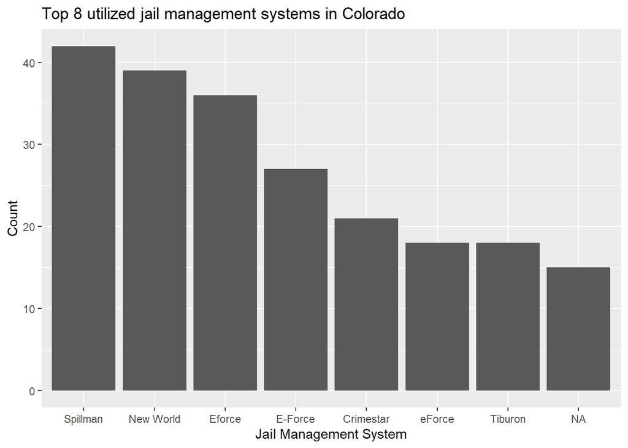

```r
colorado %>%
  count(jms) %>%
  arrange(-n) %>%
  mutate(n = n / 5) %>%
  slice(1:8) %>%
  ggplot(aes(x = reorder(jms, -n), y = n)) +
  geom_bar(stat = "identity") +
  labs(x = "Jail Management System",
       y = "Count",
       title = "Top 8 utilized jail management systems in Colorado")
```

```r
colorado_population <- colorado %>%
  arrange(qtr) %>%
  group_by(qtr) %>%
  summarise(total = sum(total))

colorado_population
```

```
## # A tibble: 3 x 2
##   qtr     total
##   <fct>   <dbl>
## 1 1     182537.
## 2 2     161983.
## 3 3     149324.
```

As you can see, Colorado jail population has significantly reduced during COVID-19.

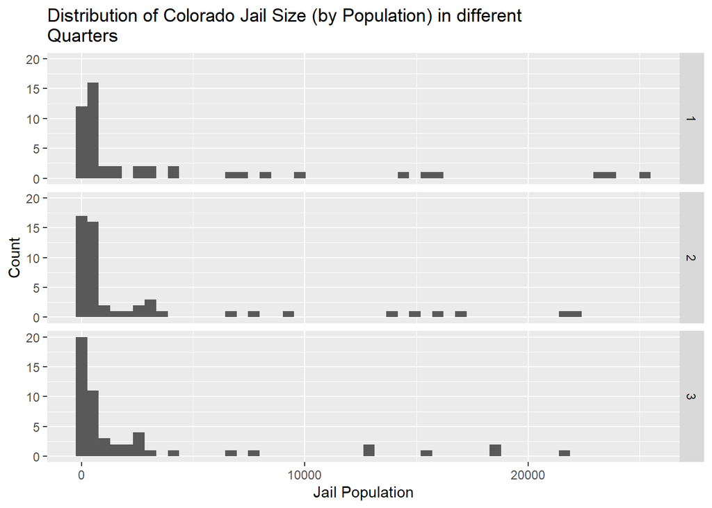

```r
# facet version

colorado_dist <- colorado %>%
  group_by(county, qtr) %>%
  summarise(total = sum(total))

colorado_dist %>%
  ggplot(aes(x = total)) +
  geom_histogram(bins = 50) +
  facet_grid(qtr ~ .) +
  labs(title = "Distribution of Colorado Jail Size (by Population) in different
Quarters",
       y = "Count",
       x = "Jail Population")
```

The population per jail throughout Colorado is Unimodal, right-skewed distribution with significant outliers on the right of the graph.

```r
colorado_dist %>%
  filter(total > 20000) %>%
  distinct(county)
```

```
## # A tibble: 3 x 1
## # Groups:   county [3]
##   county
##   <chr>
## 1 Adams
## 2 Arapahoe
## 3 El Paso
```

The largest jails in Colorado are the Adams, Arapahoe, and El Paso County Jails.

```r
total_summary <- colorado_dist %>%
  summarise(mean_total = mean(total),
    sd_total = sd(total),
    median_total = median(total),
    IQR_total = IQR(total))

total_summary
```

```
## # A tibble: 53 x 5
##    county      mean_total sd_total median_total IQR_total
##    <chr>            <dbl>    <dbl>        <dbl>     <dbl>
##  1 Adams           21225   2613.         21784     2568.
##  2 Alamosa           241     71.1          279       63
##  3 Arapahoe        21274   2593.         22393     2406.
##  4 Baca              212.    23.7          216.      23.5
##  5 Bent              590.   200.           554      198.
##  6 Boulder          8862.   924.          9089.     903.
##  7 Broomfield        550.   109.           541      109
##  8 Chaffee           382      1.73         381        1.5
##  9 Clear Creek      1219.   308.          1114      294.
## 10 Conejos           194.    66.7          180       65.5
## # ... with 43 more rows
```

# 5. Linear Regression

```r
colorado_num_inmates <- colorado %>%
  filter(measure == "Number of inmates")

colorado_num_inmates %>%
  filter(county == "Pitkin" | county == "Pueblo")
```

```
## # A tibble: 6 x 24
##   qtr_year qtr   county jms   capacity  beds deaths bookings releases measure
##      <dbl> <fct> <chr>  <chr>    <dbl> <dbl>  <dbl>    <dbl>    <dbl> <chr>
## 1     2020 1     Pueblo Spil~      780   509      0     1901     1843 Number~
## 2     2020 1     Pitkin SPIL~       30    32      1      173        0 Number~
## 3     2020 2     Pueblo Spil~      780   509      0     1889     2143 Number~
## 4     2020 2     Pitkin SPIL~       30    32      0       99       98 Number~
## 5     2020 3     Pitkin spil~       30    32      0       43       37 Number~
## 6     2020 3     Pueblo Spil~      780   509      0     1157     1213 Number~
## # ... with 14 more variables: total <dbl>, male <dbl>, female <dbl>,
## #   other_gender <dbl>, black <dbl>, native_american <dbl>, other_race <dbl>,
## #   white <dbl>, unknown_race <dbl>, non_hispanic <dbl>, hispanic <dbl>,
## #   unknown_ethnicity <dbl>, not_available <chr>, isNA <lgl>
```

Since only two jails (Pitkin and Pueblo) don’t offer information on ethnicity or race for the measure of number of total inmates in only one of their quarters, this data, focused on ethnicity counts per county, is mostly complete for modelling. We’ll remove these numbers

Let’s focus on only quarter 1 and 3:

```r
colorado_num_inmates <- colorado %>%
  filter(measure == "Number of inmates") %>%
  filter(qtr == 1 | qtr == 3)

colorado_num_inmates
```

```
## # A tibble: 100 x 24
##    qtr_year qtr   county jms   capacity  beds deaths bookings releases measure
##       <dbl> <fct> <chr>  <chr>    <dbl> <dbl>  <dbl>    <dbl>    <dbl> <chr>
##  1     2020 1     Clear~ E-Fo~      105   105      0      253      183 Number~
##  2     2020 1     Park   Jail~      255   200      0      199      191 Number~
##  3     2020 1     Eagle  Inte~      112   112      0      366      377 Number~
##  4     2020 1     El Pa~ Beac~     1837  1837      1     5161     5356 Number~
##  5     2020 1     Logan  New ~      120   120      0     1748     1731 Number~
##  6     2020 1     Baca   None        26    26      0       34       30 Number~
##  7     2020 1     San M~ Spil~       32    32      0       55       66 Number~
##  8     2020 1     Gunni~ Omni~       85    85      0      647      655 Number~
##  9     2020 1     Monte~ Efor~      104   104      0      517      495 Number~
## 10     2020 1     Pueblo Spil~      780   509      0     1901     1843 Number~
## # ... with 90 more rows, and 14 more variables: total <dbl>, male <dbl>,
## #   female <dbl>, other_gender <dbl>, black <dbl>, native_american <dbl>,
## #   other_race <dbl>, white <dbl>, unknown_race <dbl>, non_hispanic <dbl>,
## #   hispanic <dbl>, unknown_ethnicity <dbl>, not_available <chr>, isNA <lgl>
```

```r
colorado_num_inmates %>%
  count(county) %>%
  filter(n == 1)
```

```
## # A tibble: 4 x 2
##   county         n
##   <chr>      <int>
## 1 Grand          1
## 2 Huerfano       1
## 3 Las Animas     1
## 4 Saguache       1
```

Remove 4 jails that don’t have both first and third quarter: Grand, Huerfano, Las Animas, Saguache

```r
colorado_num_inmates <- colorado_num_inmates %>%
  filter(county != "Grand" &
           county != "Huerfano" &
           county != "Las Animas" &
           county != "Saguache") %>%
  select(-c(not_available, isNA, jms, qtr_year, measure, deaths,
            other_gender,
            bookings, releases)) %>%
  mutate(other_race = unknown_race + other_race) %>%
  select(-c(unknown_race)) %>%
  arrange(county)

colorado_num_inmates
```

```
## # A tibble: 96 x 14
##    qtr   county capacity  beds total  male female black native_american
##    <fct> <chr>     <dbl> <dbl> <dbl> <dbl>  <dbl> <dbl>           <dbl>
##  1 1     Adams      1271  1678   956   787    169   124               2
##  2 3     Adams      1271  1678   600   536     64    76               0
##  3 3     Alamo~      163    36    36    31      5     0               0
##  4 1     Alamo~      163    72    72    58     14     0               0
##  5 1     Arapa~     1174  1468  1115   948    167   354               4
##  6 3     Arapa~     1174  1468   628   574     53   197               5
##  7 1     Baca         26    26     7     6      1     2               0
##  8 3     Baca         26    26     6     6      0     1               0
##  9 1     Bent         62    58    47    37     10     2               0
## 10 3     Bent         96    96    29    25      4     2               0
## # ... with 86 more rows, and 5 more variables: other_race <dbl>, white <dbl>,
## #   non_hispanic <dbl>, hispanic <dbl>, unknown_ethnicity <dbl>
```

Pivot_wider;

```r
colorado_num_inmates <- colorado_num_inmates %>%
  pivot_wider(names_from = qtr, values_from = capacity:unknown_ethnicity)
```

Standardize total, race, gender, ethnicity to percentages:

```r
colorado_num_inmates <- colorado_num_inmates %>%
  mutate(difference = (total_3 - total_1)/total_1) %>%
  mutate(male_percent = male_1 / total_1) %>%
  mutate(white_percent = white_1 / total_1) %>%
  mutate(black_percent = black_1 / total_1) %>%
  mutate(native_percent = native_american_1 / total_1) %>%
  mutate(other_race_percent = other_race_1 / total_1) %>%
  mutate(non_hispanic_percent = non_hispanic_1 / total_1) %>%
  mutate(hispanic_percent = hispanic_1 / total_1) %>%
  mutate(unknown_ethnicity_percent = unknown_ethnicity_1 / total_1) %>%
  select(county, difference:unknown_ethnicity_percent)

colorado_num_inmates
```

```
## # A tibble: 48 x 10
##    county difference male_percent white_percent black_percent native_percent
##    <chr>       <dbl>        <dbl>         <dbl>         <dbl>          <dbl>
##  1 Adams      -0.372        0.823         0.859        0.130         0.00209
##  2 Alamo~     -0.5          0.806         1            0             0
##  3 Arapa~     -0.437        0.850         0.662        0.317         0.00359
##  4 Baca       -0.143        0.857         0.714        0.286         0
##  5 Bent       -0.383        0.787         0.957        0.0426        0
##  6 Bould~     -0.442        0.87          0.89         0.0775        0.015
##  7 Broom~     -0.549        0.820         0.680        0.0492        0.00820
##  8 Chaff~     -0.545        0.788         0.742        0.0303        0
##  9 Clear~     -0.186        0.886         0.829        0.143         0
## 10 Conej~     -0.831        0.723         0.985        0.0154        0
## # ... with 38 more rows, and 4 more variables: other_race_percent <dbl>,
## #   non_hispanic_percent <dbl>, hispanic_percent <dbl>,
## #   unknown_ethnicity_percent <dbl>
```

```r
full_model <- lm(difference ~
                    male_percent +
                    white_percent +
                    black_percent +
                    native_percent +
                    other_race_percent +
                    non_hispanic_percent +
                    hispanic_percent +
                    unknown_ethnicity_percent,
                  data = colorado_num_inmates)

int_only_model <- lm(difference ~ 1, data = colorado_num_inmates)

covid_model <- step(full_model, scope = formula(int_only_model), direction = "backward")
```

```
## Start:  AIC=2.06
## difference ~ male_percent + white_percent + black_percent + native_percent +
##     other_race_percent + non_hispanic_percent + hispanic_percent +
##     unknown_ethnicity_percent
##
##                             Df Sum of Sq    RSS     AIC
## - white_percent              1    0.0364 34.473  0.1103
## - other_race_percent         1    0.1694 34.606  0.2951
## - hispanic_percent           1    0.5553 34.992  0.8274
## - unknown_ethnicity_percent  1    1.0781 35.514  1.5393
## - native_percent             1    1.2244 35.661  1.7366
## <none>                                   34.436  2.0596
## - black_percent              1    2.4623 36.899  3.3746
## - non_hispanic_percent       1    7.5093 41.945  9.5282
## - male_percent               1   16.2631 50.699 18.6262
##
## Step:  AIC=0.11
## difference ~ male_percent + black_percent + native_percent +
##     other_race_percent + non_hispanic_percent + hispanic_percent +
##     unknown_ethnicity_percent
##
##                             Df Sum of Sq    RSS     AIC
## - other_race_percent         1    0.3863 34.859 -1.3548
## - hispanic_percent           1    0.5658 35.038 -1.1083
## - unknown_ethnicity_percent  1    1.2568 35.729 -0.1709
## - native_percent             1    1.3136 35.786 -0.0946
## <none>                                   34.473  0.1103
## - black_percent              1    2.7815 37.254  1.8350
## - non_hispanic_percent       1   10.3795 44.852 10.7441
## - male_percent               1   17.4923 51.965 17.8096
##
## Step:  AIC=-1.35
## difference ~ male_percent + black_percent + native_percent +
##     non_hispanic_percent + hispanic_percent + unknown_ethnicity_percent
##
##                             Df Sum of Sq    RSS     AIC
## - hispanic_percent           1    0.5901 35.449 -2.5491
## - unknown_ethnicity_percent  1    0.8706 35.730 -2.1707
## - native_percent             1    1.2172 36.076 -1.7074
## <none>                                   34.859 -1.3548
```

[output cut: 20 more lines]

```
##                             Df Sum of Sq    RSS     AIC
## - unknown_ethnicity_percent  1    1.5231 37.841 -3.4152
## <none>                                   36.318 -3.3871
## - black_percent              1    2.1518 38.469 -2.6243
## - non_hispanic_percent       1   12.2396 48.557  8.5540
## - male_percent               1   20.9978 57.315 16.5137
##
## Step:  AIC=-3.42
## difference ~ male_percent + black_percent + non_hispanic_percent
##
##                        Df Sum of Sq    RSS     AIC
## <none>                              37.841 -3.4152
## - black_percent         1    1.7294 39.570 -3.2701
## - non_hispanic_percent  1   10.8276 48.668  6.6636
## - male_percent          1   19.5447 57.385 14.5723
```

Based on backwards AIC selection, we will use the model with male_percent, black_percent, non_hispanic_percent.

```r
covid_model %>%
  tidy %>%
  kable(digits = 3)
```

| term | estimate | std.error | statistic | p.value |
| --- | --- | --- | --- | --- |
| (Intercept) | 3.830 | 0.976 | 3.925 | 0.000 |
| male_percent | -5.947 | 1.247 | -4.767 | 0.000 |
| black_percent | -2.553 | 1.800 | -1.418 | 0.163 |
| non_hispanic_percent | 1.810 | 0.510 | 3.548 | 0.001 |

To interpret this:

- All else held constant, with every percentage increase in the amount of males in a jail, we expect there to be a 6% decrease in jail population from Q1 to Q3.
- All else held constant, with every percentage increase in the amount of black people in a jail, we expect there to be a 3% decrease in jail population from Q1 to Q3.
- All else held constant, with every percentage increase in the amount of non-hispanic people in a jail, we expect there to be a 2% increase in jail population from Q1 to Q3.

Comments:

- didn’t check model conditions yet
- LOOK AT DISCHARGE
- This doesn’t look at the “after” numbers for any of the predictor variables (race, gender, ethnicity). Another thing we can do in the future is analyze the difference between races over time.
- are the race variables independent enough?
- try looking at which race percentage decreases the most
- look at bed increases or decreases
- look at capacity changes
- make helper functions to streamline the creation of other regression models

Ideas:

RQ: Is there a difference between the proportion of people released from COVID-19 between races? Gender?

- ANova means to asess whether there’s been a significant change due to COVID-19
- Look at Legalization, COVID-19, COVID-19 on Race
- How do I research whether having a larger percentage of Black people made jails more/less likely to release people?
- Add judiciary political, national political, county political (assembly member elected)
- ggmap